# MLR3 Overview

Evan Carey

## Overview from the docs

> > The (Machine Learning in R) mlr3 (Lang et al. 2019) package and ecosystem provide a generic, object-oriented, and extensible framework for classification, regression, survival analysis, and other machine learning tasks for the R language (R Core Team 2019) (task types are discussed in detail in ?sec-tasks-types). This unified interface provides functionality to extend and combine existing machine learning algorithms (learners), intelligently select and tune the most appropriate technique for a specific machine learning task, and perform large-scale comparisons that enable meta-learning. Examples of this advanced functionality include hyperparameter tuning (Chapter 4) and feature selection (Chapter 5). Parallelization of many operations is natively supported (Section 9.1).

> > mlr3 has similar overall aims to caret, tidymodels, scikit-learn for Python, and MLJ for Julia. In general mlr3, is designed to provide more flexibility than other machine learning frameworks while still offering easy ways to use advanced functionality. While in particular tidymodels makes it very easy to perform simple machine learning tasks, mlr3 is more geared towards advanced machine learning. To get a quick overview of how to do things in the mlr3verse, see the mlr3 cheatsheets1.

Review this introduction chapter for more details:

https://mlr3book.mlr-org.com/intro.html

## Reasons I use MLR3

- Leverages data.table - fast and efficient for big data
- Easy to run in parallel and control total resource utilization
- Low level control for stacked modeling efforts

```r
# load all neede packages
library(mlr3verse)
```

## Non-linear complex DGP number 4

Let’s go back to our prior example of a complex data generating process:

```r
# simulate some data, continuous outcome
set.seed(42)
n_obs <- 10000
# simulate x1 (continuous)
x1 <- rlnorm(n = n_obs,
             meanlog = log(4),
             sdlog = log(1.2))
# simulate x2 (binary)
x2 <- rbinom(n = n_obs,
             size = 1,
             prob = 0.3)

# simulate y, now conditional on X1 and X2
y_mean <-
  8 +
  ifelse(x1>4,
         -4*x2,
         3*x2) +
  2*scale(x1) +
  -4*scale(x1)*x2 +
  -4*log(x1)*x2

y_sd <- 3
y <- rnorm(n = n_obs,
           mean = y_mean,
           sd = y_sd)

# make dataframe
df4 <- data.table(y,
                  x1,
                  x2)
# check it out
df4
```

| y | x1 | x2 |
| --- | --- | --- |
| -8.470536e+00 | 5.135872 | 1 |
| 4.537509e+00 | 3.608664 | 0 |
| 4.893334e+00 | 4.273788 | 0 |
| -6.201173e+00 | 4.489220 | 1 |
| 1.382197e+01 | 4.305965 | 0 |
| 1.663726e+01 | 3.923349 | 0 |
| 1.872928e+01 | 5.269194 | 0 |
| 9.068285e+00 | 3.931559 | 0 |
| -4.057158e+00 | 5.779381 | 1 |
| 8.928802e+00 | 3.954524 | 0 |

[output cut: 9990 more lines]

## Create/load dataset

MLR3 starts by defining a `task`. This is essentially the dataset we will be working on. We identify this as a regression task, pass in data, and identify the target.

```r
# create a task
regr_task <-
  as_task_regr(df4,
               target = 'y')
```

```r
# examine task traits
regr_task
```

```
## <TaskRegr:df4> (10000 x 3)
## * Target: y
## * Properties: -
## * Features (2):
##   - dbl (1): x1
##   - int (1): x2
```

We can access the outcome using the `$truth()`:

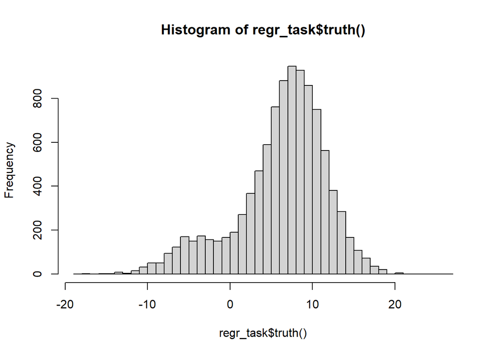

```r
# check data
hist(regr_task$truth(), breaks = 50)
```

Recall the data generating process - we can access the underlying data from the task using `$data()`

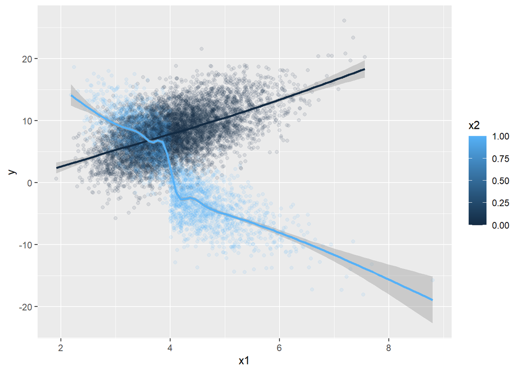

```r
# visualize the relationship
library(ggplot2)
ggplot(regr_task$data(),aes(x1,y,group=x2, color=x2)) +
  geom_point(alpha=0.1) +
  geom_smooth()
```

## Implement a single learner

We will start by implementing a single learning algorithm. Prior to that, we need to split the dataset. We will do this manually for now, but will show how to do it differently in a moment.

```r
# split data into 80/20 split - get row indices
# You could also use partition() here, but I do not show it
set.seed(34)
train_ind <-
  sample(1:nrow(df4),
         size = nrow(df4)*.8)
```

After we establish the task, we next establish the ‘learner’. We identify a linear model as the learner.

```r
# get linear model
learner_lm = lrn('regr.lm')
learner_lm
```

```
## <LearnerRegrLM:regr.lm>
## * Model: -
## * Parameters: list()
## * Packages: mlr3, mlr3learners, stats
## * Predict Types:  [response], se
## * Feature Types: logical, integer, numeric, character, factor
## * Properties: loglik, weights
```

After establishing the learner, we can train it like so:

```r
# fit linear model
learner_lm$train(regr_task,
                 row_ids = train_ind)
# check the model components
learner_lm$model
```

```
##
## Call:
## stats::lm(formula = task$formula(), data = task$data())
##
## Coefficients:
## (Intercept)           x1           x2
##     10.0676      -0.5042      -5.9646
```

We can now make predictions on the holdout dataset. Note the prediction object contains the original truth values and the predictions.

```r
# predict using the hold out data
prediction_lm <-
  learner_lm$predict_newdata(newdata = regr_task$data()[-train_ind])

# check out resulting object
print(prediction_lm)
```

```
## <PredictionRegr> for 2000 observations:
##     row_ids    truth response
##           1 9.892892 8.592858
##           2 4.017263 8.768894
##           3 9.926203 8.496048
## ---
##        1998 5.131532 8.414995
##        1999 7.071656 2.087399
##        2000 9.969550 7.190882
```

Now we can assess performance. MLR3 contains many different performance measures -

```r
head(as.data.table(mlr_measures))
```

| key | label | task_type | packages | predict_type | task_properties |
| --- | --- | --- | --- | --- | --- |
| aic | Akaika Information Criterion | NA |  | response |  |
| bic | Bayesian Information Criterion | NA |  | response |  |
| classif.acc | Classification Accuracy | classif |  | response |  |
| classif.auc | Area Under the ROC Curve | classif |  | prob |  |
| classif.bacc | Balanced Accuracy | classif |  | response |  |
| classif.bbrier | Binary Brier Score | classif |  | prob |  |

Let’s review just the regression measures.

```r
as.data.table(mlr_measures)[task_type=='regr']
```

| key | label | task_type | packages | predict_type | task_properties |
| --- | --- | --- | --- | --- | --- |
| regr.bias | Bias | regr |  | response |  |
| regr.ktau | Kendall's tau | regr |  | response |  |
| regr.mae | Mean Absolute Error | regr |  | response |  |
| regr.mape | Mean Absolute Percent Error | regr |  | response |  |
| regr.maxae | Max Absolute Error | regr |  | response |  |
| regr.medae | Median Absolute Error | regr |  | response |  |
| regr.medse | Median Squared Error | regr |  | response |  |
| regr.mse | Mean Squared Error | regr |  | response |  |
| regr.msle | Mean Squared Log Error | regr |  | response |  |
| regr.pbias | Percent Bias | regr |  | response |  |

[output cut: 10 more lines]

We create an object with multiple measures, then we can score the predictions.

```r
# ask for multiple scores back
measures1 <- msrs(c("regr.mae", "regr.mse"))
scores <- prediction_lm$score(measures1)
print(scores)
```

```
##  regr.mae  regr.mse
##  3.858336 22.855240
```

## Using the resample functionality

Instead of manually doing the hold-out samples, we can use the resampling functionality of `MLR3`.

```r
# single hold out
rr_holdout <-
  rsmp("holdout", ratio=0.8)
print(rr_holdout)
```

```
## <ResamplingHoldout>: Holdout
## * Iterations: 1
## * Instantiated: FALSE
## * Parameters: ratio=0.8
```

We initiate the resampling object like so:

```r
# initiate resampling
rr1 <-
  resample(regr_task,
           learner_lm,
           rsmp("holdout", ratio=0.8))
```

```
## INFO  [00:04:13.447] [mlr3] Applying learner 'regr.lm' on task 'df4' (iter 1/1)
```

```r
print(rr1)
```

```
## <ResampleResult> of 1 iterations
## * Task: df4
## * Learner: regr.lm
## * Warnings: 0 in 0 iterations
## * Errors: 0 in 0 iterations
```

This triggered the model fitting. As above we need to ask for the actual scores on the resulting object.

```r
# check scores
measures1 <- msrs(c("regr.mae", "regr.mse"))
rr1$score(measures1)
```

| task | task_id | learner | learner_id | resampling | resampling_id | iteration | prediction | regr.mae | regr.mse |
| --- | --- | --- | --- | --- | --- | --- | --- | --- | --- |
|  | df4 |  | regr.lm |  | holdout | 1 |  | 3.763644 | 22.22736 |

## 5-fold resampling

Instead of a simple holdout, we can do k-folds cross validation to use all of the data efficiently. See this link for more info on k-folds cross validation:

https://en.wikipedia.org/wiki/Cross-validation_(statistics)

```r
# 5 fold resample
cv_5 <-
  rsmp("cv", folds = 5)
print(cv_5)
```

```
## <ResamplingCV>: Cross-Validation
## * Iterations: 5
## * Instantiated: FALSE
## * Parameters: folds=5
```

Note the instantiate == FALSE - this means it has not yet been established with respect to a dataset (task).

We call resample to initiate the model fits across all resamples:

```r
# instantiate resampling
rr2 <-
  resample(regr_task,
           learner_lm,
           cv_5)
```

```
## INFO  [00:04:13.635] [mlr3] Applying learner 'regr.lm' on task 'df4' (iter 1/5)
## INFO  [00:04:13.660] [mlr3] Applying learner 'regr.lm' on task 'df4' (iter 2/5)
## INFO  [00:04:13.679] [mlr3] Applying learner 'regr.lm' on task 'df4' (iter 3/5)
## INFO  [00:04:13.699] [mlr3] Applying learner 'regr.lm' on task 'df4' (iter 4/5)
## INFO  [00:04:13.719] [mlr3] Applying learner 'regr.lm' on task 'df4' (iter 5/5)
```

```r
print(rr2)
```

```
## <ResampleResult> of 5 iterations
## * Task: df4
## * Learner: regr.lm
## * Warnings: 0 in 0 iterations
## * Errors: 0 in 0 iterations
```

We can now request scores as before:

```r
# check scores
measures1 <- msrs(c("regr.mae", "regr.mse"))
rr2$score(measures1)
```

| task | task_id | learner | learner_id | resampling | resampling_id | iteration | prediction | regr.mae | regr.mse |
| --- | --- | --- | --- | --- | --- | --- | --- | --- | --- |
|  | df4 |  | regr.lm |  | cv | 1 |  | 3.956229 | 24.52876 |
|  | df4 |  | regr.lm |  | cv | 2 |  | 3.909223 | 23.05135 |
|  | df4 |  | regr.lm |  | cv | 3 |  | 3.655214 | 21.55929 |
|  | df4 |  | regr.lm |  | cv | 4 |  | 3.726441 | 21.60285 |
|  | df4 |  | regr.lm |  | cv | 5 |  | 3.853472 | 22.88436 |

If we want to aggregate to a single measure, there is an aggregate method available:

```r
## aggregate the measures
rr2$aggregate(measures = measures1)
```

```
##  regr.mae  regr.mse
##  3.820116 22.725322
```

We can use autoplot to see the distribution of the results.

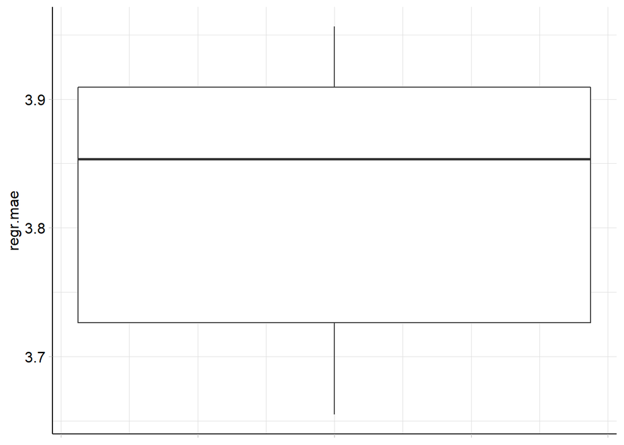

```r
# check distribution of results
# pick a single measure
library("mlr3viz")
autoplot(rr2, measure = msr("regr.mae"))
```

## Implement a random forest

Checkout this link for more info:  
https://en.wikipedia.org/wiki/Random_forest

```r
# declare resampling, fit models
rr <-
  resample(regr_task,
           lrn("regr.ranger"),
           rsmp("cv", folds = 3))
```

```
## INFO  [00:04:14.221] [mlr3] Applying learner 'regr.ranger' on task 'df4' (iter 1/3)
## INFO  [00:04:14.750] [mlr3] Applying learner 'regr.ranger' on task 'df4' (iter 2/3)
## INFO  [00:04:15.201] [mlr3] Applying learner 'regr.ranger' on task 'df4' (iter 3/3)
```

```r
print(rr)
```

```
## <ResampleResult> of 3 iterations
## * Task: df4
## * Learner: regr.ranger
## * Warnings: 0 in 0 iterations
## * Errors: 0 in 0 iterations
```

```r
# check scores
measures1 <- msrs(c("regr.mae", "regr.mse"))
rr$score(measures1)
```

| task | task_id | learner | learner_id | resampling | resampling_id | iteration | prediction | regr.mae | regr.mse |
| --- | --- | --- | --- | --- | --- | --- | --- | --- | --- |
|  | df4 |  | regr.ranger |  | cv | 1 |  | 2.696757 | 11.47070 |
|  | df4 |  | regr.ranger |  | cv | 2 |  | 2.564065 | 10.38839 |
|  | df4 |  | regr.ranger |  | cv | 3 |  | 2.651895 | 10.91837 |

```r
## aggregate the measures
rr$aggregate(measures = measures1)
```

```
##  regr.mae  regr.mse
##  2.637572 10.925821
```

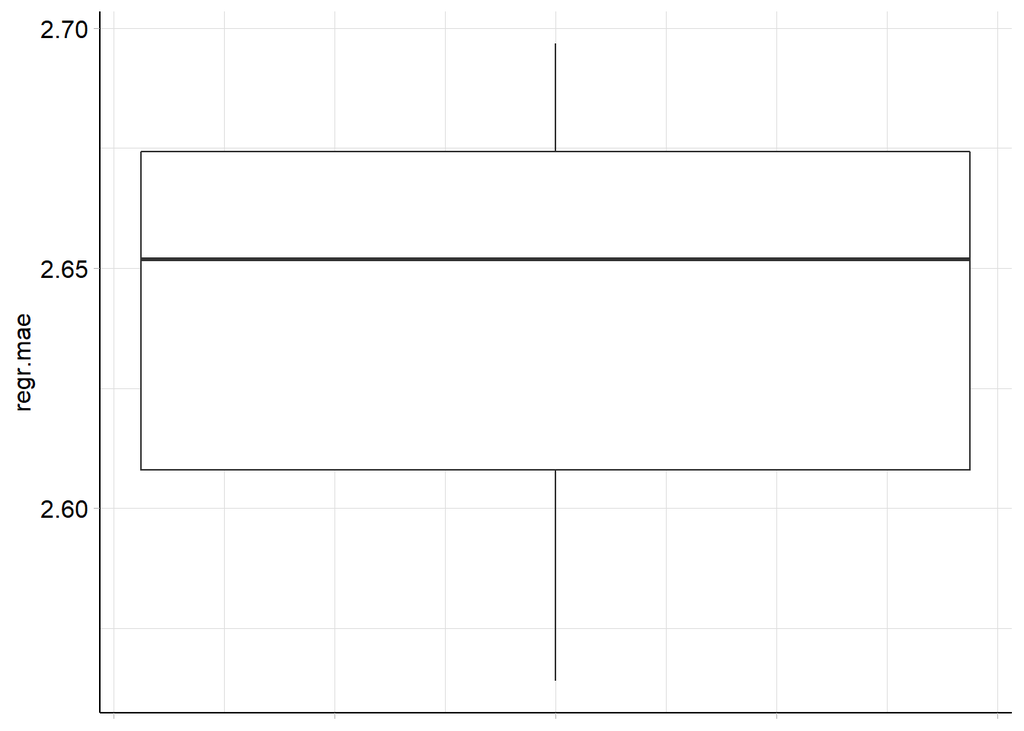

```r
# check distribution of results
# pick a single measure
autoplot(rr, measure = msr("regr.mae"))
```

## Hyperparameter optimization

We have not yet discussed model hyperparameters. Model parameters are something you are familiar with from linear regression - for example the beta coefficients. Model hyper parameters are not quite the same…they are parameters that we set overtly, as opposed to parameters that are optimized internally in the model fit.

In the context of a random forest, we can set (At least) the following hyperparameters:

- mtry: Number of variables to possibly split at in each node
- min node size: Minimal node size (number of rows)

However, what are the best values for these? We can optimize them by searching the parameter space. We try different combinations of parameters, then see what gives us the best predictive performance.

MLR3 has an auto-tuner functionality where we can create a new learner that performs hyper-parameter optimization:

```r
# setup auto tuner for ranger
at_ranger <- auto_tuner(
  method = tnr("random_search"),
  learner = lrn("regr.ranger",
              min.node.size = to_tune(5, 100),
              mtry = to_tune(1, 2)),
  resampling = rsmp("cv", folds = 3),
  measure = msr("regr.mae"),
  terminator = trm("evals", n_evals= 5)
)
at_ranger$id <- 'ranger_tuned'
```

After defining it, we can use it just like any other learner (but it will be slower).

```r
# instantiate resampling
rr3 <-
  resample(regr_task,
           at_ranger,
           rsmp("cv", folds = 3))
```

[output not shown]

[output cut: 128 more lines]

[output not shown]

```r
print(rr3)
```

```
## <ResampleResult> of 3 iterations
## * Task: df4
## * Learner: ranger_tuned
## * Warnings: 0 in 0 iterations
## * Errors: 0 in 0 iterations
```

```r
# check scores
measures1 <- msrs(c("regr.mae", "regr.mse"))
rr3$score(measures1)
```

| task | task_id | learner | learner_id | resampling | resampling_id | iteration | prediction | regr.mae | regr.mse |
| --- | --- | --- | --- | --- | --- | --- | --- | --- | --- |
|  | df4 |  | ranger_tuned |  | cv | 1 |  | 2.696410 | 11.247951 |
|  | df4 |  | ranger_tuned |  | cv | 2 |  | 2.477112 | 9.608239 |
|  | df4 |  | ranger_tuned |  | cv | 3 |  | 2.466323 | 9.553378 |

```r
## aggregate the measures
rr3$aggregate(measures = measures1)
```

```
##  regr.mae  regr.mse
##  2.546615 10.136523
```

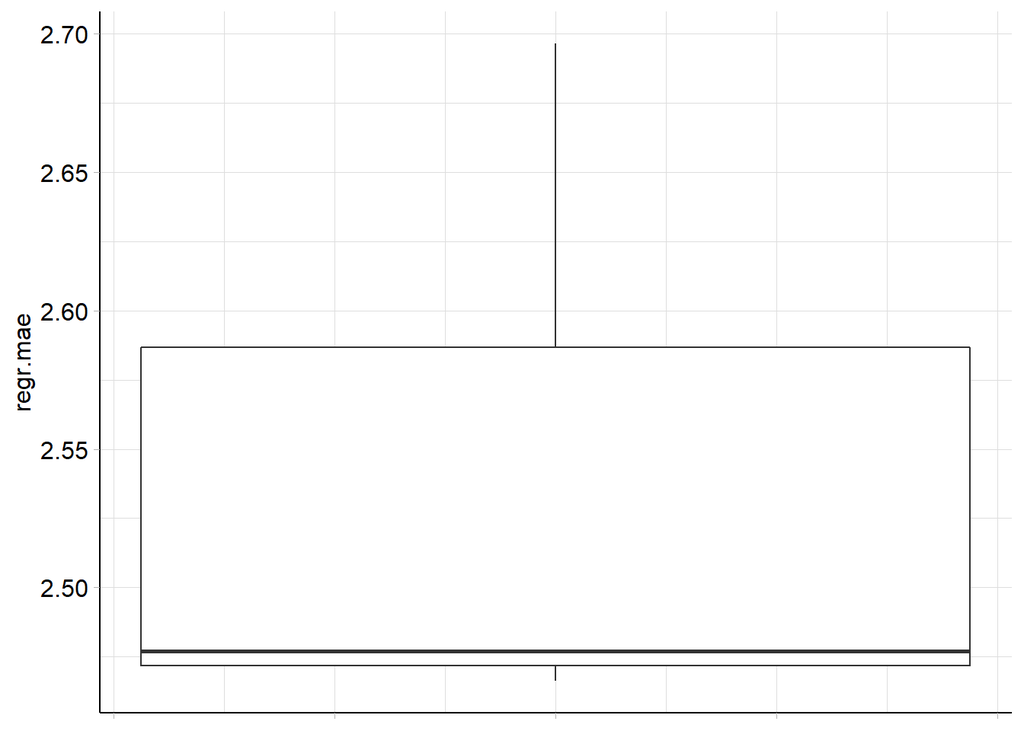

```r
# check distribution of results
# pick a single measure
library("mlr3viz")
autoplot(rr3, measure = msr("regr.mae"))
```

## Benchmarking multiple algorithms

A common task is to compare multiple different learning algorithms (run an ML experiment), then report the results.

This is called ‘benchmarking’.

`MLR3` implements benchmarking using similar syntax as above.

We need to declare the following:

- tasks (we could use multiple datasets)
- learners to test (which could include autotuners)
- resampling scheme for the benchmark

```r
# establish design
design = benchmark_grid(
  task = regr_task,
  learners = lrns(c("regr.lm", "regr.ranger", "regr.xgboost"),
                  predict_sets = c("train", "test")),
  resamplings = rsmps("cv", folds = 3)
)
print(design)
```

```
##              task                  learner         resampling
## 1: <TaskRegr[47]>      <LearnerRegrLM[37]> <ResamplingCV[20]>
## 2: <TaskRegr[47]>  <LearnerRegrRanger[38]> <ResamplingCV[20]>
## 3: <TaskRegr[47]> <LearnerRegrXgboost[37]> <ResamplingCV[20]>
```

After defining the benchmark grid, we call the benchmark function to initiate the training.

```r
# execute experiment
bmr = benchmark(design)
```

```
## INFO  [00:05:09.611] [mlr3] Running benchmark with 9 resampling iterations
## INFO  [00:05:09.617] [mlr3] Applying learner 'regr.lm' on task 'df4' (iter 1/3)
## INFO  [00:05:09.645] [mlr3] Applying learner 'regr.lm' on task 'df4' (iter 2/3)
## INFO  [00:05:09.674] [mlr3] Applying learner 'regr.lm' on task 'df4' (iter 3/3)
## INFO  [00:05:09.701] [mlr3] Applying learner 'regr.ranger' on task 'df4' (iter 1/3)
## INFO  [00:05:10.364] [mlr3] Applying learner 'regr.ranger' on task 'df4' (iter 2/3)
## INFO  [00:05:11.033] [mlr3] Applying learner 'regr.ranger' on task 'df4' (iter 3/3)
## INFO  [00:05:11.666] [mlr3] Applying learner 'regr.xgboost' on task 'df4' (iter 1/3)
## INFO  [00:05:11.715] [mlr3] Applying learner 'regr.xgboost' on task 'df4' (iter 2/3)
## INFO  [00:05:11.751] [mlr3] Applying learner 'regr.xgboost' on task 'df4' (iter 3/3)
## INFO  [00:05:11.781] [mlr3] Finished benchmark
```

We can review the summary of the warnings and errors here:

```r
# show summary
bmr
```

```
## <BenchmarkResult> of 9 rows with 3 resampling runs
##  nr task_id   learner_id resampling_id iters warnings errors
##   1     df4      regr.lm            cv     3        0      0
##   2     df4  regr.ranger            cv     3        0      0
##   3     df4 regr.xgboost            cv     3        0      0
```

You check the results by requesting the measures to be calculated. Here we identify both testing and training, and both MSE and MAE:

```r
# check results
measures1 <-
  list(msr("regr.mae",predict_sets = "train", id = "mae_train"),
       msr("regr.mse",predict_sets = "train", id = "mse_train"),
       msr("regr.mae",predict_sets = "test", id = "mae_test"),
       msr("regr.mse",predict_sets = "test", id = "mse_test"))

tab = bmr$aggregate(measures1)
print(tab[, .(task_id, learner_id, mae_train, mae_test,mse_train,mse_test)])
```

```
##    task_id   learner_id mae_train mae_test mse_train mse_test
## 1:     df4      regr.lm  3.816700 3.821751  22.67252 22.72539
## 2:     df4  regr.ranger  2.611357 2.633141  10.66610 10.89744
## 3:     df4 regr.xgboost  5.115883 5.122601  35.55417 35.70883
```

We can plot the results as before.

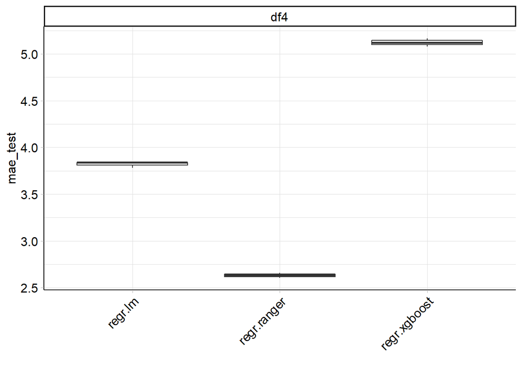

```r
# show MAE Results
autoplot(bmr,
         measure = msr("regr.mae",
                       predict_sets = "test",
                       id = "mae_test"))
```

See this discussion for extracting a model from the benchmark for further prediction purposes:

https://github.com/mlr-org/mlr3/issues/601

## Conclusion

MLR3 is an efficient and fast framework for implementing ML in R using native packages.

Check out the MLR3 book for more in-depth details on how to use this package:

https://mlr3book.mlr-org.com/

Also you can check out the general website:

https://mlr3.mlr-org.com/